# Spatial Interpolation Overview

Arsalan Anwari

2023-06-05

# 1. Data preparation

## 1.1 Load libraries

```r
options("rgdal_show_exportToProj4_warnings"="none")

library(jsonlite) # used for wind speed data of knmi station
library(sf) # used to load maps and manipulate spatial features

# used to plot maps and other figures
library(ggplot2)
library(gridExtra) # to create nxn facets for ggplot

library(tidyverse) # used for piping functionality of data manipulation functions

# Used to fix conflicted packages of dplyr
library(conflicted)
conflict_prefer("filter", "dplyr")
conflict_prefer("lag", "dplyr")

library(gstat) # used for interpolation and validation of IDW and kriging models
library(caret) # used for cross validation of other models
```

## 1.2 Load data

```r
# load windspeed measurements
df_knmi_windspeed <- read_json("Data/knmi_winspeed_days_2017.json", simplifyVector = TRUE)
df_knmi_station_coords <- read.csv( "Data/knmi_weather_stations.csv", sep=";")

crs_source <- readRDS("Data/source_map_crs.rds")
sf_netherlands <- st_read("Data/netherlands_reference_map.gpkg")
ls_best_rmse_weights <- readRDS("Data/weights_with_lowest_rmse_per_opt.rds")
```

## 1.3 Clean windspeed data

### 1.3.1 Rename windspeed dataframe columns

```r
df_knmi_windspeed <- df_knmi_windspeed %>%
  select(station_code, date, FG) %>%
  rename(windspeed = FG)
```

### 1.3.3 Find missing entries and na values

```r
missing_rows_stations <- df_knmi_windspeed %>%
  group_by(station_code) %>%
  summarise(n = n()) %>%
  filter(n < 365) %>%
  select(station_code)

na_rows_stations <- df_knmi_windspeed %>%
  filter(is.na(windspeed)) %>%
  select(station_code)

missing_knmi_stations <- unique(rbind(missing_rows_stations, na_rows_stations))

missing_knmi_stations$station_code
```

```
## [1] 323 257 285
```

### 1.3.3 filter out rows with missing entries

```r
df_knmi_windspeed <- df_knmi_windspeed %>%
  filter(!(station_code %in% missing_knmi_stations$station_code))
```

## 1.4 Merge location data of `df_knmi_station_coords` with windspeed data of `df_knmi_windspeed` into new variable

```r
df_knmi_station_coords <- df_knmi_station_coords %>%
  select(STN, LON, LAT, NAME) %>%
  rename(station_code = STN, x=LON, y=LAT, station_name=NAME)

df_knmi_stations <- merge(df_knmi_windspeed, df_knmi_station_coords, by = "station_code")

head(df_knmi_stations)
```

```
##   station_code                     date windspeed     x      y station_name
## 1          209 2017-01-01T00:00:00.000Z        95 4.518 52.465       IJmond
## 2          209 2017-01-02T00:00:00.000Z        88 4.518 52.465       IJmond
## 3          209 2017-01-03T00:00:00.000Z       109 4.518 52.465       IJmond
## 4          209 2017-01-04T00:00:00.000Z       130 4.518 52.465       IJmond
## 5          209 2017-01-05T00:00:00.000Z        57 4.518 52.465       IJmond
## 6          209 2017-01-06T00:00:00.000Z        69 4.518 52.465       IJmond
```

## 1.5 Fix datetime and restructure order of dataframe

```r
df_knmi_stations <- df_knmi_stations %>%
  mutate(date=strftime(date, "%d-%m-%Y")) %>%
  mutate(date=as.Date(date, "%d-%m-%Y")) %>%
  select(station_code, station_name, date, x, y, windspeed)
```

```r
sf_netherlands <- sf_netherlands %>%
  st_geometry() %>%
  st_transform(crs_source)

grid_spacing <- 5000

gs_netherlands_grid <- sf_netherlands %>%
  st_make_grid(
    square = TRUE,
    what = "polygons",
    cellsize = c(grid_spacing, grid_spacing)
  )

sf_netherlands_grid <- gs_netherlands_grid %>% st_sf()

sf_netherlands_grid
```

```
## Simple feature collection with 3456 features and 0 fields
## Geometry type: POLYGON
## Dimension:     XY
## Bounding box:  xmin: 10425.32 ymin: 306846 xmax: 280425.3 ymax: 626846
## Projected CRS: Amersfoort / RD New
## First 10 features:
##                          geometry
## 1  POLYGON ((10425.32 306846, ...
## 2  POLYGON ((15425.32 306846, ...
## 3  POLYGON ((20425.32 306846, ...
## 4  POLYGON ((25425.32 306846, ...
## 5  POLYGON ((30425.32 306846, ...
## 6  POLYGON ((35425.32 306846, ...
## 7  POLYGON ((40425.32 306846, ...
## 8  POLYGON ((45425.32 306846, ...
## 9  POLYGON ((50425.32 306846, ...
## 10 POLYGON ((55425.32 306846, ...
```

## 1.7 Remove seatiles and other unneccesary tiles

```r
sf_netherlands_grid <- sf_netherlands_grid %>%
  mutate(cell_id = 1:length(lengths(gs_netherlands_grid))) # add cell ID

sf_netherlands_grid$n_intersects <- lengths(
  st_intersects(sf_netherlands_grid, sf_netherlands)
)

sf_netherlands_grid <- sf_netherlands_grid %>%
  filter(n_intersects > 0) %>%
  select(geometry, cell_id)

sf_netherlands_grid
```

```
## Simple feature collection with 1813 features and 1 field
## Geometry type: POLYGON
## Dimension:     XY
## Bounding box:  xmin: 10425.32 ymin: 306846 xmax: 280425.3 ymax: 626846
## Projected CRS: Amersfoort / RD New
## First 10 features:
##    cell_id                       geometry
## 1       34 POLYGON ((175425.3 306846, ...
## 2       35 POLYGON ((180425.3 306846, ...
## 3       36 POLYGON ((185425.3 306846, ...
## 4       37 POLYGON ((190425.3 306846, ...
## 5       38 POLYGON ((195425.3 306846, ...
## 6       87 POLYGON ((170425.3 311846, ...
## 7       88 POLYGON ((175425.3 311846, ...
## 8       89 POLYGON ((180425.3 311846, ...
## 9       90 POLYGON ((185425.3 311846, ...
## 10      91 POLYGON ((190425.3 311846, ...
```

## 1.8 Show map of grids

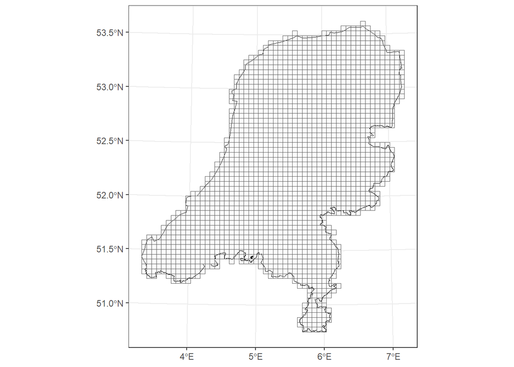

```r
ggplot() +
  geom_sf(data = sf_netherlands, fill="white", col="black") +
  geom_sf(data = sf_netherlands_grid, alpha=0.1) +
  theme_bw()
```

# 2. Observation and receptor preparation

## 2.1 Take single sample of knmi windspeed timeseries as observations

```r
df_observations <- df_knmi_stations %>%
  filter(date == as.Date("2017-01-01")) %>%
  select(!date)

sf_observations <- df_observations %>%
  st_as_sf(coords = c("x", "y")) %>%
  st_set_crs(4326) %>% # WGS-84
  st_transform(crs_source)

sf_observations
```

```
## Simple feature collection with 44 features and 3 fields
## Geometry type: POINT
## Dimension:     XY
## Bounding box:  xmin: 6075.776 ymin: 324093.6 xmax: 272803.2 ymax: 603272.3
## Projected CRS: Amersfoort / RD New
## First 10 features:
##    station_code       station_name windspeed                  geometry
## 1           209             IJmond        95   POINT (95931.09 497827)
## 2           215        Voorschoten        50 POINT (89954.25 461848.9)
## 3           225           IJmuiden        95 POINT (98442.88 497574.9)
## 4           235            De Kooy        64 POINT (114235.5 549163.1)
## 5           240           Schiphol        53 POINT (114280.3 481284.2)
## 6           242           Vlieland        95   POINT (123874.8 583925)
## 7           248           Wijdenes        71 POINT (140566.3 516298.3)
## 8           249           Berkhout        54 POINT (127371.4 517467.6)
## 9           251 Hoorn Terschelling        79 POINT (152258.4 600630.4)
## 10          258        Houtribdijk       100 POINT (155933.6 517946.2)
```

```r
head(df_observations, 10)
```

```
##    station_code       station_name     x      y windspeed
## 1           209             IJmond 4.518 52.465        95
## 2           215        Voorschoten 4.437 52.141        50
## 3           225           IJmuiden 4.555 52.463        95
## 4           235            De Kooy 4.781 52.928        64
## 5           240           Schiphol 4.790 52.318        53
## 6           242           Vlieland 4.921 53.241        95
## 7           248           Wijdenes 5.174 52.634        71
## 8           249           Berkhout 4.979 52.644        54
## 9           251 Hoorn Terschelling 5.346 53.392        79
## 10          258        Houtribdijk 5.401 52.649       100
```

## 2.2 Find grid which intersect with observations.

```r
sf_receptors <- sf_netherlands_grid
sf_receptors$station_codes <- c(st_intersects(sf_netherlands_grid, sf_observations))
```

### 2.2.1 Create backup grid for plotting

```r
sf_receptors_copy <- sf_netherlands_grid
sf_receptors_copy$station_codes <- c(st_intersects(sf_netherlands_grid, sf_observations))
sf_netherlands_receptor_grid <- sf_receptors_copy %>% filter(lengths(station_codes) == 0)

sf_netherlands_receptor_grid
```

```
## Simple feature collection with 1772 features and 2 fields
## Geometry type: POLYGON
## Dimension:     XY
## Bounding box:  xmin: 10425.32 ymin: 306846 xmax: 280425.3 ymax: 626846
## Projected CRS: Amersfoort / RD New
## First 10 features:
##    cell_id                       geometry station_codes
## 1       34 POLYGON ((175425.3 306846, ...
## 2       35 POLYGON ((180425.3 306846, ...
## 3       36 POLYGON ((185425.3 306846, ...
## 4       37 POLYGON ((190425.3 306846, ...
## 5       38 POLYGON ((195425.3 306846, ...
## 6       87 POLYGON ((170425.3 311846, ...
## 7       88 POLYGON ((175425.3 311846, ...
## 8       89 POLYGON ((180425.3 311846, ...
## 9       90 POLYGON ((185425.3 311846, ...
## 10      91 POLYGON ((190425.3 311846, ...
```

## 2.3 Apply found indexes of intersects with windspeed values.

```r
# R has a weird bug where using the mean() function over a flattend list of length 1 used  will take the mean of the entire data frame instead of the selection.
# Therefor two separate search operations are performed, the results combined # with each other and finally merged with the receptor array.

single_intersects <- sf_receptors %>%
  as.data.frame() %>%
  select(cell_id, station_codes) %>%
  filter(lengths(station_codes) == 1) %>%
  mutate(windspeed = df_observations$windspeed[unlist(station_codes)]) %>%
  select(cell_id, windspeed)

multi_intersects <- sf_receptors %>%
  as.data.frame() %>%
  select(cell_id, station_codes) %>%
  filter(lengths(station_codes) > 1) %>%
  mutate(windspeed = mean(df_observations$windspeed[unlist(station_codes)])) %>%
  select(cell_id, windspeed)

all_intersects <- rbind(single_intersects, multi_intersects)

sf_observations <- merge(sf_receptors, all_intersects, by="cell_id")
```

```r
sf_observations
```

```
## Simple feature collection with 41 features and 3 fields
## Geometry type: POLYGON
## Dimension:     XY
## Bounding box:  xmin: 10425.32 ymin: 321846 xmax: 275425.3 ymax: 606846
## Projected CRS: Amersfoort / RD New
## First 10 features:
##    cell_id station_codes windspeed                       geometry
## 1      197            43        52 POLYGON ((180425.3 321846, ...
## 2      521            42        42 POLYGON ((180425.3 351846, ...
## 3      548            30        50 POLYGON ((45425.32 356846, ...
## 4      757            24        59 POLYGON ((10425.32 376846, ...
## 5      815            25        69 POLYGON ((30425.32 381846, ...
## 6      820            28        67 POLYGON ((55425.32 381846, ...
## 7      825            34        33 POLYGON ((80425.32 381846, ...
## 8      839            40        41 POLYGON ((150425.3 381846, ...
## 9      877            33        71 POLYGON ((70425.32 386846, ...
## 10     905            44        40 POLYGON ((210425.3 386846, ...
```

## 2.4 Calculate the centroids of the receptors are use that as the geometry instead of polygons.

```r
sf_receptors <- sf_receptors %>%
  st_set_geometry(st_centroid(st_geometry(sf_receptors)))

sf_observations <- sf_observations %>%
  st_set_geometry(st_centroid(st_geometry(sf_observations)))
```

## 2.5 Set default value of 0 for receptor variables

```r
sf_receptors <- sf_receptors %>% mutate(windspeed = 0)
```

## 2.6 Remove observation cells from receptor grid

```r
sf_receptors <- sf_receptors %>%
  filter(lengths(station_codes) == 0)
```

## 2.7 Prepare and save data for other R scripts like dynamic model traning routine

```r
sf_observations_anual <- df_knmi_stations %>%
  st_as_sf(coords = c("x", "y")) %>%
  st_set_crs(4326) %>% # WGS-84
  st_transform(crs_source)
```

```r
sf_receptors <- sf_receptors %>%
  mutate(
    x = st_coordinates(.)[,1],
    y = st_coordinates(.)[,2]
  )

sf_observations <- sf_observations %>%
  mutate(
    x = st_coordinates(.)[,1],
    y = st_coordinates(.)[,2]
  )

sf_observations_anual <- sf_observations_anual %>%
  mutate(
    x = st_coordinates(.)[,1],
    y = st_coordinates(.)[,2]
  )
```

```r
saveRDS(sf_observations, "Data/knmi_windspeed_observations_training_set.rds")
saveRDS(sf_observations_anual, "Data/knmi_windspeed_complete_set.rds")
saveRDS(sf_receptors, "Data/knmi_windspeed_receptors_training_set.rds")
```

# 3. Spatial intepolation methods

The optimal weights are calculated such that they perform well on average across all available days in the year 2017. For some models it is possible that omitting the weights will actual yield a lower RMSE for a **specific** day but generally speaking will yield a higher RMSE on average when taking **all** days into account.

## 3.1 Show best combination of weights and settings for spatial interpolation of training set

```r
ls_best_rmse_weights$trend_surface
```

```
##       model_opt_name case_weight     rmse
## 1     model = linear    1.151302 13.15603
## 2 model = hyperbolic    1.000508 13.60280
```

```r
ls_best_rmse_weights$mqrbf
```

```
##                 model_opt_name alpha_weight     rmse
## 1 smoothing factor = 12.019620     1.166435 13.42134
## 2  smoothing factor = 3.004133     1.166435 13.42134
## 3 smoothing factor = 61.296304     1.166434 13.42134
## 4 smoothing factor = 90.770461     1.166434 13.42133
## 5  smoothing factor = 6.502520     1.166435 13.42134
```

```r
ls_best_rmse_weights$idw
```

```
##   model_opt_name      idp     rmse
## 1  neighbors = 5 1.025381 14.30482
## 2  neighbors = 6 1.028791 13.96801
## 3  neighbors = 7 1.015099 14.25143
## 4  neighbors = 8 1.010350 14.26551
```

```r
ls_best_rmse_weights$od_kriging
```

```
## # A tibble: 4 × 4
##   model_opt_name psill range  rmse
##   <chr>          <dbl> <dbl> <dbl>
## 1 neighbors = 5  0.343  34.3  14.1
## 2 neighbors = 6  0.364  36.4  13.7
## 3 neighbors = 7  0.389  38.9  14.2
## 4 neighbors = 8  0.433  43.3  14.3
```

```r
ls_best_rmse_weights$u_kriging
```

```
## # A tibble: 6 × 4
##   model_opt_name                    psill range  rmse
##   <chr>                             <dbl> <dbl> <dbl>
## 1 neighbors = 5, model = linear     0.286  28.6  15.6
## 2 neighbors = 5, model = hyperbolic 0.533  53.3  14.2
## 3 neighbors = 6, model = linear     0.439  43.9  14.3
## 4 neighbors = 6, model = hyperbolic 0.503  50.3  13.7
## 5 neighbors = 7, model = linear     0.438  43.8  15.0
## 6 neighbors = 7, model = hyperbolic 0.498  49.8  14.1
```

Based on these results best case models will use the following weights in this manner:

- Linear and hyperbolic trend surface using `weights = (1/windspeed) + case_weight`
- MQ-RBF model with an `alpha_seed = 1.166434` and `smoothing_factor = 90.770461`
- IDW model using `nmax=6` and `idp=1.028791`
- Ordinary kriging using spherical variogram using `vgm(base_range + 36.41014, "Sph", base_psill + 0.3641014)` where `base_range` and `base_psill` where pre-calculated by fitting the variogram using `fit.variogram(...)` and `nmax=6`
- Universal kriging with linear and hyperbolic regression model using `psill=0.4390736, range=43.90736, nmax=6` and `psill=0.5031153, range=50.31153, nmax=6`.

## 3.2 Train spatial interpolation models

### 3.2.1 Trend surface

```r
model.trend_surface.linear.best_case <- lm(
  formula = windspeed ~ x + y,
  data = sf_observations,
  weights = (1 / windspeed) + 1.151302
)

model.trend_surface.hyperbolic.best_case <- lm(
  formula = windspeed ~ x + y + I(x^2) + (x * y) + I(y^2) + I(x^3) + (I(x^2) * y) + (x * I(y^2)) + I(y^3),
  data = sf_observations,
  weights = (1 / windspeed) + 1.000508
)

model.trend_surface.linear.avg_case <- lm(
  formula = windspeed ~ x + y,
  data = sf_observations
)

model.trend_surface.hyperbolic.avg_case <- lm(
  formula = windspeed ~ x + y + I(x^2) + (x * y) + I(y^2) + I(x^3) + (I(x^2) * y) + (x * I(y^2)) + I(y^3),
  data = sf_observations
)

summary(model.trend_surface.linear.best_case)
```

```
##
## Call:
## lm(formula = windspeed ~ x + y, data = sf_observations, weights = (1/windspeed) +
##     1.151302)
##
## Weighted Residuals:
##     Min      1Q  Median      3Q     Max
## -22.972  -8.430  -1.847   7.197  40.484
##
## Coefficients:
##               Estimate Std. Error t value Pr(>|t|)
## (Intercept)  1.155e+01  1.257e+01   0.919  0.36394
## x           -1.451e-04  3.426e-05  -4.235  0.00014 ***
## y            1.421e-04  2.979e-05   4.770 2.72e-05 ***
## ---
## Signif. codes:  0 '***' 0.001 '**' 0.01 '*' 0.05 '.' 0.1 ' ' 1
##
## Residual standard error: 13.73 on 38 degrees of freedom
## Multiple R-squared:  0.4254, Adjusted R-squared:  0.3951
## F-statistic: 14.06 on 2 and 38 DF,  p-value: 2.681e-05
```

```r
summary(model.trend_surface.hyperbolic.best_case)
```

```
##
## Call:
## lm(formula = windspeed ~ x + y + I(x^2) + (x * y) + I(y^2) +
##     I(x^3) + (I(x^2) * y) + (x * I(y^2)) + I(y^3), data = sf_observations,
##     weights = (1/windspeed) + 1.000508)
##
## Weighted Residuals:
##     Min      1Q  Median      3Q     Max
## -18.009  -4.686  -0.200   4.299  41.051
##
## Coefficients:
##               Estimate Std. Error t value Pr(>|t|)
## (Intercept)  4.368e+02  5.765e+02   0.758    0.454
## x            1.504e-03  1.539e-03   0.977    0.336
## y           -2.990e-03  3.521e-03  -0.849    0.402
## I(x^2)      -1.255e-09  5.501e-09  -0.228    0.821
## I(y^2)       7.237e-09  7.208e-09   1.004    0.323
## I(x^3)      -9.463e-17  1.293e-14  -0.007    0.994
## I(y^3)      -4.998e-15  5.199e-15  -0.961    0.344
## x:y         -6.167e-09  7.950e-09  -0.776    0.444
## y:I(x^2)     5.411e-15  2.102e-14   0.257    0.799
## x:I(y^2)     3.598e-15  1.323e-14   0.272    0.788
##
## Residual standard error: 12.67 on 31 degrees of freedom
## Multiple R-squared:  0.5421, Adjusted R-squared:  0.4091
## F-statistic: 4.077 on 9 and 31 DF,  p-value: 0.00157
```

```r
summary(model.trend_surface.linear.avg_case)
```

```
##
## Call:
## lm(formula = windspeed ~ x + y, data = sf_observations)
##
## Residuals:
##     Min      1Q  Median      3Q     Max
## -21.164  -7.827  -1.756   6.629  37.527
##
## Coefficients:
##               Estimate Std. Error t value Pr(>|t|)
## (Intercept)  1.154e+01  1.258e+01   0.917  0.36493
## x           -1.453e-04  3.431e-05  -4.234  0.00014 ***
## y            1.422e-04  2.981e-05   4.771 2.71e-05 ***
## ---
## Signif. codes:  0 '***' 0.001 '**' 0.01 '*' 0.05 '.' 0.1 ' ' 1
##
## Residual standard error: 12.71 on 38 degrees of freedom
## Multiple R-squared:  0.4253, Adjusted R-squared:  0.3951
## F-statistic: 14.06 on 2 and 38 DF,  p-value: 2.686e-05
```

```r
summary(model.trend_surface.hyperbolic.avg_case)
```

```
##
## Call:
## lm(formula = windspeed ~ x + y + I(x^2) + (x * y) + I(y^2) +
##     I(x^3) + (I(x^2) * y) + (x * I(y^2)) + I(y^3), data = sf_observations)
##
## Residuals:
##     Min      1Q  Median      3Q     Max
## -17.791  -4.704  -0.239   4.262  40.778
##
## Coefficients:
##               Estimate Std. Error t value Pr(>|t|)
## (Intercept)  4.399e+02  5.774e+02   0.762    0.452
## x            1.500e-03  1.541e-03   0.973    0.338
## y           -3.009e-03  3.527e-03  -0.853    0.400
## I(x^2)      -1.262e-09  5.508e-09  -0.229    0.820
## I(y^2)       7.276e-09  7.219e-09   1.008    0.321
## I(x^3)      -3.775e-17  1.296e-14  -0.003    0.998
## I(y^3)      -5.027e-15  5.207e-15  -0.965    0.342
## x:y         -6.148e-09  7.961e-09  -0.772    0.446
## y:I(x^2)     5.360e-15  2.106e-14   0.255    0.801
## x:I(y^2)     3.599e-15  1.325e-14   0.272    0.788
##
## Residual standard error: 12.57 on 31 degrees of freedom
## Multiple R-squared:  0.5414, Adjusted R-squared:  0.4083
## F-statistic: 4.067 on 9 and 31 DF,  p-value: 0.001598
```

### 3.2.2 MQ-RBF

- Load external R script to make notebook cleaner.

```r
source("mqrbf-model-simple.R")
args(mqrbf) # Used to define model
```

```
## function (data, alpha_seed = 1, smoothing_factor = 0)
## NULL
```

```r
args(predict.mqrbf) # Used to predict surface
```

```
## function (object, newdata)
## NULL
```

```r
args(train.mqrbf) # Used for SLOO-CV
```

```
## function (model)
## NULL
```

```r
model.mqrbf.best_case <- mqrbf(
    data = sf_observations,
    alpha_seed = 1.166434,
    smoothing_factor = 90.770461
)

model.mqrbf.avg_case <- mqrbf(data = sf_observations)

cat("\n model.mqrbf.best_case$alpha_weight \n")
```

```
##
##  model.mqrbf.best_case$alpha_weight
```

```r
summary(model.mqrbf.best_case$alpha_weights)
```

```
##       Min.    1st Qu.     Median       Mean    3rd Qu.       Max.
## -1.913e-03 -1.984e-04  3.183e-05  8.468e-06  3.733e-04  1.609e-03
```

```r
cat("\n model.mqrbf.avg_case$alpha_weight \n")
```

```
##
##  model.mqrbf.avg_case$alpha_weight
```

```r
summary(model.mqrbf.avg_case$alpha_weights)
```

```
##       Min.    1st Qu.     Median       Mean    3rd Qu.       Max.
## -2.066e-03 -2.143e-04  3.438e-05  9.146e-06  4.031e-04  1.737e-03
```

### 3.2.3 IDW

```r
model.idw.best_case <- gstat(
  formula = windspeed ~ 1,
  data = sf_observations,
  nmax = 6,
  set = list(idp = 1.028791)
)

model.idw.avg_case <- gstat(
  formula = windspeed ~ 1,
  data = sf_observations,
  nmax = 6,
  set = list(idp = 1.0)
)

model.idw.best_case
```

```
## data:
## var1 : formula = windspeed`~`1 ; data dim = 41 x 5 nmax = 6
## set idp = 1.028791;
```

```r
cat("\n")
```

```r
model.idw.avg_case
```

```
## data:
## var1 : formula = windspeed`~`1 ; data dim = 41 x 5 nmax = 6
## set idp = 1;
```

### 3.2.4 Ordinary kriging

```r
vgm.od_kriging <- variogram(windspeed ~ 1, data = sf_observations)
```

[output not shown]

```r
model.od_kriging.vgm.avg_case <- suppressWarnings(fit.variogram(vgm.od_kriging, vgm("Sph")))

best_psill <- model.od_kriging.vgm.avg_case$psill[1] + 0.3641014
best_range <- model.od_kriging.vgm.avg_case$range[2] + 36.41014

model.od_kriging.vgm.best_case <- suppressWarnings(
  fit.variogram(vgm.od_kriging, vgm(best_psill, model = "Sph", best_range))
)

cat(sprintf("
  avg_psill = %f; best_psill = %f
  avg_range = %f; best_range = %f
",
  model.od_kriging.vgm.avg_case$psill[1], best_psill,
  model.od_kriging.vgm.avg_case$range[2], best_range
))
```

```
##
##   avg_psill = 348.342080; best_psill = 348.706182
##   avg_range = 40943.119350; best_range = 40979.529490
```

```r
model.od_kriging.best_case <- gstat(
  formula = windspeed ~ 1,
  data = sf_observations,
  nmax = 6,
  model = model.od_kriging.vgm.best_case
)

model.od_kriging.avg_case <- gstat(
  formula = windspeed ~ 1,
  data = sf_observations,
  nmax = 6,
  model = model.od_kriging.vgm.avg_case
)
```

### 3.2.5 Universal kriging

```r
vgm.u_kriging <- variogram(windspeed ~ x + y, data = sf_observations)
model.u_kriging.vgm.avg_case <- suppressWarnings(fit.variogram(vgm.u_kriging, vgm("Sph")))

best_psill.linear <- model.u_kriging.vgm.avg_case$psill[1] + 0.4390736
best_range.linear <- model.u_kriging.vgm.avg_case$range[2] + 43.90736
best_psill.hyperbolic <- model.u_kriging.vgm.avg_case$psill[1] + 0.5031153
best_range.hyperbolic <- model.u_kriging.vgm.avg_case$range[2] + 50.31153

model.u_kriging.vgm.best_case.linear <- suppressWarnings(
  fit.variogram(vgm.od_kriging, vgm(best_psill.linear, model = "Sph", best_range.linear))
)

model.u_kriging.vgm.best_case.hyperbolic <- suppressWarnings(
  fit.variogram(vgm.od_kriging, vgm(best_psill.hyperbolic, model = "Sph", best_range.hyperbolic))
)

cat(sprintf("
  [Linear]
  avg_psill = %f; best_psill = %f
  avg_range = %f; best_range = %f

  [Hyperbolic]
  avg_psill = %f; best_psill = %f
  avg_range = %f; best_range = %f
",
  model.u_kriging.vgm.avg_case$psill[1], best_psill.linear,
  model.u_kriging.vgm.avg_case$range[2], best_range.linear,
  model.u_kriging.vgm.avg_case$psill[1], best_psill.hyperbolic,
  model.u_kriging.vgm.avg_case$range[2], best_range.hyperbolic
))
```

```
##
##   [Linear]
##   avg_psill = 292.162214; best_psill = 292.601287
##   avg_range = 40943.119350; best_range = 40987.026710
##
##   [Hyperbolic]
##   avg_psill = 292.162214; best_psill = 292.665329
##   avg_range = 40943.119350; best_range = 40993.430880
```

- The syntax for a `formula` in the `variogram()` function is unconventional. Here `windspeed ~ x+y` simply indicates “variogram optimized for universal kriging” and `windspeed ~ 1` indicates simple or ordinary kriging.

```r
model.u_kriging.linear.best_case <- gstat(
  formula = windspeed ~ x + y,
  data = sf_observations,
  nmax = 6,
  model = model.u_kriging.vgm.best_case.linear
)

model.u_kriging.hyperbolic.best_case <- gstat(
  formula = windspeed ~ abs(x + y + (x^2) + (x * y) + (y^2) + (x^3) + ((x^2) * y) + (x * (y^2)) + (y^3)),
  data = sf_observations,
  nmax = 6,
  model = model.u_kriging.vgm.best_case.hyperbolic
)

model.u_kriging.linear.avg_case <- gstat(
  formula = windspeed ~ x + y,
  data = sf_observations,
  nmax = 6,
  model = model.u_kriging.vgm.avg_case
)

model.u_kriging.hyperbolic.avg_case <- gstat(
  formula = windspeed ~ abs(x + y + (x^2) + (x * y) + (y^2) + (x^3) + ((x^2) * y) + (x * (y^2)) + (y^3)),
  data = sf_observations,
  nmax = 6,
  model = model.u_kriging.vgm.avg_case
)
```

- The syntax for the `formula` parameter is unconventional in the `gstat()` function. Exponents do not need a `I(x^n)` clause and `abs()` is used to indicate that a higher order polynomial regression model is used without auxiliary variables. To use auxiliary variables for something like co-kriging you need to remove the `abs(....)` and use `log(windspeed)`.

# 4. Calculate RMSE and NRMSE for each model

## 4.1 Define helper functions

### 4.1.1 RMSE and NRMSE functions

```r
calc_rmse <- function(residuals) {
  return(sqrt(sum((residuals)^2)/length(residuals)))
}

calc_nrmse <- function(rmse){
  return( rmse / sd(sf_observations$windspeed) )
}
```

### 4.1.2 Decorator for SLOO-CV crossvalidation function for models using `gstat` library

```r
train.gstat <- function(model){
  { sink(nullfile()); cv <- gstat.cv(model, nfold = nrow(sf_observations), verbose=FALSE); sink(); }
  return( list(residuals = cv$residual) )
}
```

- The `gstat.cv()` function has the tendency to output all training epochs in the terminal, making for unnecessary long knitted html files. Using `sink(nullfile())` is equivalent to piping all output of a command to `/dev/null`. This removes the output visually in the generated html file.

## 4.2 Calculate RMSE and NRMSE for each weighted and non weighted model

### 4.2.1 Trend surface

```r
# Calc RMSE using SLOO-CV
results.trend_surface.linear.best_case <- train(
  windspeed ~ x + y,
  method = "lm",
  data = sf_observations,
  trControl = trainControl(method = "LOOCV"),
  weights = (1 / windspeed) + 1.151302
)

results.trend_surface.hyperbolic.best_case <- train(
  windspeed ~ x + y + I(x^2) + (x * y) + I(y^2) + I(x^3) + (I(x^2) * y) + (x * I(y^2)) + I(y^3),
  method = "lm",
  data = sf_observations,
  trControl = trainControl(method = "LOOCV"),
  weights = (1 / windspeed) + 1.000508
)

results.trend_surface.linear.avg_case <- train(
  windspeed ~ x + y,
  method = "lm",
  data = sf_observations,
  trControl = trainControl(method = "LOOCV")
)

results.trend_surface.hyperbolic.avg_case <- train(
  windspeed ~ x + y + I(x^2) + (x * y) + I(y^2) + I(x^3) + (I(x^2) * y) + (x * I(y^2)) + I(y^3),
  method = "lm",
  data = sf_observations,
  trControl = trainControl(method = "LOOCV")
)

# Calc NRMSE from RMSE
results.trend_surface.linear.rmse.best_case <- calc_rmse(resid(results.trend_surface.hyperbolic.best_case))
results.trend_surface.linear.nrmse.best_case <- calc_nrmse(results.trend_surface.linear.rmse.best_case)

results.trend_surface.hyperbolic.rmse.best_case <- calc_rmse(resid(results.trend_surface.hyperbolic.best_case))
results.trend_surface.hyperbolic.nrmse.best_case <- calc_nrmse(results.trend_surface.hyperbolic.rmse.best_case)

results.trend_surface.linear.rmse.avg_case <- calc_rmse(resid(results.trend_surface.linear.avg_case))
results.trend_surface.linear.nrmse.avg_case <- calc_nrmse(results.trend_surface.linear.rmse.avg_case)

results.trend_surface.hyperbolic.rmse.avg_case <- calc_rmse(resid(results.trend_surface.hyperbolic.avg_case))
results.trend_surface.hyperbolic.nrmse.avg_case <- calc_nrmse(results.trend_surface.hyperbolic.rmse.avg_case)
```

### 4.2.2 MQ-RBF

```r
# Calc RMSE using SLOO-CV
results.mqrbf.best_case <- train.mqrbf(model.mqrbf.best_case)
results.mqrbf.avg_case <- train.mqrbf(model.mqrbf.avg_case)

# Calc NRMSE from RMSE
results.mqrbf.rmse.best_case <- calc_rmse(results.mqrbf.best_case$residuals)
results.mqrbf.nrmse.best_case <- calc_nrmse(results.mqrbf.rmse.best_case)

results.mqrbf.rmse.avg_case <- calc_rmse(results.mqrbf.avg_case$residuals)
results.mqrbf.nrmse.avg_case <- calc_nrmse(results.mqrbf.rmse.avg_case)
```

### 4.2.3 IDW

```r
# Calc RMSE using SLOO-CV
results.idw.best_case <- train.gstat(model.idw.best_case)
results.idw.avg_case <- train.gstat(model.idw.avg_case)

# Calc NRMSE from RMSE
results.idw.rmse.best_case <- calc_rmse(results.idw.best_case$residuals)
results.idw.nrmse.best_case <- calc_nrmse(results.idw.rmse.best_case)

results.idw.rmse.avg_case <- calc_rmse(results.idw.avg_case$residuals)
results.idw.nrmse.avg_case <- calc_nrmse(results.idw.rmse.avg_case)
```

### 4.2.4 Ordinary kriging

```r
# Calc RMSE using SLOO-CV
results.od_kriging.best_case <- train.gstat(model.od_kriging.best_case)
results.od_kriging.avg_case <- train.gstat(model.od_kriging.avg_case)

# Calc NRMSE from RMSE
results.od_kriging.rmse.best_case <- calc_rmse(results.od_kriging.best_case$residuals)
results.od_kriging.nrmse.best_case <- calc_nrmse(results.od_kriging.rmse.best_case)

results.od_kriging.rmse.avg_case <- calc_rmse(results.od_kriging.avg_case$residuals)
results.od_kriging.nrmse.avg_case <- calc_nrmse(results.od_kriging.rmse.avg_case)
```

### 4.2.5 Universal kriging

```r
# Calc RMSE using SLOO-CV
results.u_kriging.linear.best_case <- train.gstat(model.u_kriging.linear.best_case)
results.u_kriging.hyperbolic.best_case <- train.gstat(model.u_kriging.hyperbolic.best_case)

results.u_kriging.linear.avg_case <- train.gstat(model.u_kriging.linear.avg_case)
results.u_kriging.hyperbolic.avg_case <- train.gstat(model.u_kriging.hyperbolic.avg_case)

# Calc NRMSE from RMSE
results.u_kriging.linear.rmse.best_case <- calc_rmse(results.u_kriging.linear.best_case$residuals)
results.u_kriging.linear.nrmse.best_case <- calc_nrmse(results.u_kriging.linear.rmse.best_case)

results.u_kriging.hyperbolic.rmse.best_case <- calc_rmse(results.u_kriging.hyperbolic.best_case$residuals)
results.u_kriging.hyperbolic.nrmse.best_case <- calc_nrmse(results.u_kriging.hyperbolic.rmse.best_case)

results.u_kriging.linear.rmse.avg_case <- calc_rmse(results.u_kriging.linear.avg_case$residuals)
results.u_kriging.linear.nrmse.avg_case <- calc_nrmse(results.u_kriging.linear.rmse.avg_case)

results.u_kriging.hyperbolic.rmse.avg_case <- calc_rmse(results.u_kriging.hyperbolic.avg_case$residuals)
results.u_kriging.hyperbolic.nrmse.avg_case <- calc_nrmse(results.u_kriging.hyperbolic.rmse.avg_case)
```

## 4.3 Combine and show RMSE and NRMSE results of models

```r
model_names <- c(
  "Trend surface (1st order)",
  "Trend surface (3rd order)",
  "MQ-RBF",
  "IDW",
  "Ordinary kriging",
  "Universal kriging (1st order)",
  "Universal kriging (3rd order)"
)

best_case_weights <- c(
  "case_weight = 1.151302",
  "case_weight = 1.000508",
  "alpha_seed = 1.166434; smoothing_factor = 90.770461",
  "nmax=6; idp=1.028791",
  "vgm=\"Sph\"; psill=348.3421; range=40943.12; nmax=6",
  "vgm=\"Sph\"; psill=188.709; range=13714.15; nmax=6",
  "vgm=\"Sph\"; psill=188.7081; range=13714.12; nmax=6"
)

best_case_rmse_values <- c(
  results.trend_surface.linear.rmse.best_case,
  results.trend_surface.hyperbolic.rmse.best_case,
  results.mqrbf.rmse.best_case,
  results.idw.rmse.best_case,
  results.od_kriging.rmse.best_case,
  results.u_kriging.linear.rmse.best_case,
  results.u_kriging.hyperbolic.rmse.best_case
)

best_case_nrmse_values <- c(
  results.trend_surface.linear.nrmse.best_case,
  results.trend_surface.hyperbolic.nrmse.best_case,
  results.mqrbf.nrmse.best_case,
  results.idw.nrmse.best_case,
  results.od_kriging.nrmse.best_case,
  results.u_kriging.linear.nrmse.best_case,
  results.u_kriging.hyperbolic.nrmse.best_case
)

avg_case_rmse_values <- c(
  results.trend_surface.linear.rmse.avg_case,
  results.trend_surface.hyperbolic.rmse.avg_case,
  results.mqrbf.rmse.avg_case,
  results.idw.rmse.avg_case,
  results.od_kriging.rmse.avg_case,
  results.u_kriging.linear.rmse.avg_case,
  results.u_kriging.hyperbolic.rmse.avg_case
)

avg_case_nrmse_values <- c(
  results.trend_surface.linear.nrmse.avg_case,
  results.trend_surface.hyperbolic.nrmse.avg_case,
  results.mqrbf.nrmse.avg_case,
  results.idw.nrmse.avg_case,
  results.od_kriging.nrmse.avg_case,
  results.u_kriging.linear.nrmse.avg_case,
  results.u_kriging.hyperbolic.nrmse.avg_case
)

results.all_models <-
  data.frame(
    model_name = model_names,
    best_case_weight = best_case_weights,
    rmse.best_case = best_case_rmse_values,
    rmse.avg_case = avg_case_rmse_values,
    nrmse.best_case = best_case_nrmse_values,
    nrmse.avg_case = avg_case_nrmse_values
  )
```

# 5. Compare models

## 5.1 Show difference in RMSE and NRMSE between best case and average case models

```r
results.all_models %>% select(model_name, rmse.best_case, rmse.avg_case, nrmse.best_case, nrmse.avg_case)
```

```
##                      model_name rmse.best_case rmse.avg_case nrmse.best_case
## 1     Trend surface (1st order)       10.92801      12.23348       0.6688704
## 2     Trend surface (3rd order)       10.92801      10.92795       0.6688704
## 3                        MQ-RBF       13.77851      13.48196       0.8433411
## 4                           IDW       13.98033      13.96693       0.8556939
## 5              Ordinary kriging       13.70217      13.62906       0.8386682
## 6 Universal kriging (1st order)       14.32642      14.28966       0.8768769
## 7 Universal kriging (3rd order)       13.66884      13.62607       0.8366282
##   nrmse.avg_case
## 1      0.7487742
## 2      0.6688665
## 3      0.8251900
## 4      0.8548732
## 5      0.8341937
## 6      0.8746269
## 7      0.8340102
```

## 5.2 Generate surfaces

### 5.2.1 Trend surface

```r
preds.trend_surface.linear.best_case <- predict(model.trend_surface.linear.best_case, sf_receptors)
preds.trend_surface.hyperbolic.best_case <- predict(model.trend_surface.hyperbolic.best_case, sf_receptors)

preds.trend_surface.linear.avg_case <- predict(model.trend_surface.linear.avg_case, sf_receptors)
preds.trend_surface.hyperbolic.avg_case <- predict(model.trend_surface.hyperbolic.avg_case, sf_receptors)

cat("\n preds.trend_surface.linear.best_case \n")
```

```
##
##  preds.trend_surface.linear.best_case
```

```r
summary(preds.trend_surface.linear.best_case)
```

```
##    Min. 1st Qu.  Median    Mean 3rd Qu.    Max.
##   26.79   48.67   56.59   55.67   63.40   77.47
```

```r
cat("\n preds.trend_surface.hyperbolic.best_case \n")
```

```
##
##  preds.trend_surface.hyperbolic.best_case
```

```r
summary(preds.trend_surface.hyperbolic.best_case)
```

```
##    Min. 1st Qu.  Median    Mean 3rd Qu.    Max.
##   36.35   44.24   54.63   55.04   64.35   88.30
```

```r
cat("\n preds.trend_surface.linear.avg_case \n")
```

```
##
##  preds.trend_surface.linear.avg_case
```

```r
summary(preds.trend_surface.linear.avg_case)
```

```
##    Min. 1st Qu.  Median    Mean 3rd Qu.    Max.
##   26.79   48.70   56.63   55.70   63.44   77.53
```

```r
cat("\n preds.trend_surface.hyperbolic.avg_case \n")
```

```
##
##  preds.trend_surface.hyperbolic.avg_case
```

```r
summary(preds.trend_surface.hyperbolic.avg_case)
```

```
##    Min. 1st Qu.  Median    Mean 3rd Qu.    Max.
##   36.35   44.26   54.67   55.07   64.37   88.32
```

### 5.2.2 MQ-RBF

```r
preds.mqrbf.best_case <- predict.mqrbf(model.mqrbf.best_case, sf_receptors)
preds.mqrbf.avg_case <- predict.mqrbf(model.mqrbf.avg_case, sf_receptors)

cat("\n preds.mqrbf.best_case \n")
```

```
##
##  preds.mqrbf.best_case
```

```r
summary(preds.mqrbf.best_case)
```

```
##    Min. 1st Qu.  Median    Mean 3rd Qu.    Max.
##   31.40   39.55   48.18   50.17   59.59   88.11
```

```r
cat("\n preds.mqrbf.avg_case \n")
```

```
##
##  preds.mqrbf.avg_case
```

```r
summary(preds.mqrbf.avg_case)
```

```
##    Min. 1st Qu.  Median    Mean 3rd Qu.    Max.
##   33.91   42.72   52.03   54.19   64.36   95.16
```

### 5.2.3 IDW

```r
preds.idw.best_case <- predict(model.idw.best_case, sf_receptors)$var1.pred
```

```
## [inverse distance weighted interpolation]
```

```r
preds.idw.avg_case <- predict(model.idw.avg_case, sf_receptors)$var1.pred
```

```
## [inverse distance weighted interpolation]
```

```r
cat("\n preds.idw.best_case \n")
```

```
##
##  preds.idw.best_case
```

```r
summary(preds.idw.best_case)
```

```
##    Min. 1st Qu.  Median    Mean 3rd Qu.    Max.
##   36.90   44.38   55.58   55.18   63.78   85.15
```

```r
cat("\n preds.idw.avg_case \n")
```

```
##
##  preds.idw.avg_case
```

```r
summary(preds.idw.avg_case)
```

```
##    Min. 1st Qu.  Median    Mean 3rd Qu.    Max.
##   36.98   44.40   55.66   55.19   63.76   84.71
```

### 5.2.4 Ordinary kriging

```r
preds.od_kriging.best_case <- predict(model.od_kriging.best_case, sf_receptors)$var1.pred
```

```
## [using ordinary kriging]
```

```r
preds.od_kriging.avg_case <- predict(model.od_kriging.avg_case, sf_receptors)$var1.pred
```

```
## [using ordinary kriging]
```

```r
cat("\n preds.od_kriging.best_case \n")
```

```
##
##  preds.od_kriging.best_case
```

```r
summary(preds.od_kriging.best_case)
```

```
##    Min. 1st Qu.  Median    Mean 3rd Qu.    Max.
##   37.65   44.50   56.00   55.40   63.03   83.09
```

```r
cat("\n preds.od_kriging.avg_case \n")
```

```
##
##  preds.od_kriging.avg_case
```

```r
summary(preds.od_kriging.avg_case)
```

```
##    Min. 1st Qu.  Median    Mean 3rd Qu.    Max.
##   39.50   44.50   56.17   55.38   62.67   76.83
```

### 5.2.5 Universal kriging

```r
preds.u_kriging.linear.best_case <- predict(model.u_kriging.linear.best_case, sf_receptors)$var1.pred
```

```
## [using universal kriging]
```

```r
preds.u_kriging.hyperbolic.best_case <- predict(model.u_kriging.hyperbolic.best_case, sf_receptors)$var1.pred
```

```
## [using universal kriging]
```

```r
preds.u_kriging.linear.avg_case <- predict(model.u_kriging.linear.avg_case, sf_receptors)$var1.pred
```

```
## [using universal kriging]
```

```r
preds.u_kriging.hyperbolic.avg_case <- predict(model.u_kriging.hyperbolic.avg_case, sf_receptors)$var1.pred
```

```
## [using universal kriging]
```

```r
cat("\n preds.u_kriging.linear.best_case \n")
```

```
##
##  preds.u_kriging.linear.best_case
```

```r
summary(preds.u_kriging.linear.best_case)
```

```
##    Min. 1st Qu.  Median    Mean 3rd Qu.    Max.
##   37.26   44.44   54.56   55.80   65.93   92.62
```

```r
cat("\n preds.u_kriging.hyperbolic.best_case \n")
```

```
##
##  preds.u_kriging.hyperbolic.best_case
```

```r
summary(preds.u_kriging.hyperbolic.best_case)
```

```
##    Min. 1st Qu.  Median    Mean 3rd Qu.    Max.
##   37.46   44.91   56.38   55.97   64.87   82.43
```

```r
cat("\n preds.u_kriging.linear.avg_case \n")
```

```
##
##  preds.u_kriging.linear.avg_case
```

```r
summary(preds.u_kriging.linear.avg_case)
```

```
##    Min. 1st Qu.  Median    Mean 3rd Qu.    Max.
##   38.20   44.64   54.75   55.85   65.82   89.06
```

```r
cat("\n preds.u_kriging.hyperbolic.avg_case \n")
```

```
##
##  preds.u_kriging.hyperbolic.avg_case
```

```r
summary(preds.u_kriging.hyperbolic.avg_case)
```

```
##    Min. 1st Qu.  Median    Mean 3rd Qu.    Max.
##   37.81   45.23   56.93   55.98   64.74   82.29
```

## 5.3 Show surfaces

### 5.3.1 Define function to generate map plot

```r
create_prediction_map <- function(observation_variables, title_text, subtitle_text, caption_text){

  sf_netherlands_receptor_grid$windspeed <- 0
  sf_netherlands_receptor_grid$windspeed <- as.factor(ceiling(observation_variables / 10))

  map_plot <- ggplot() +
    geom_sf(
      data = sf_netherlands_receptor_grid,
      aes(fill = windspeed)
    ) +
    scale_fill_grey(start = 0.1, end = 0.9) +
    labs(
      title = title_text,
      subtitle = subtitle_text,
      fill = "windspeed (m/s)",
      caption = caption_text
    ) +
    theme_bw() +
    theme(legend.position = "bottom",
          legend.direction = "horizontal",
          axis.text.x=element_blank(),
          axis.text.y=element_blank()
    )

  return(map_plot)
}
```

### 5.3.2 Generate map plots

```r
map_plot.trend_surface.linear.best_case <- create_prediction_map(
  preds.trend_surface.linear.best_case,
  title_text = "Trend surface (1st order)",
  subtitle_text = "[best_case]",
  caption_text = "case_weight = 1.151302"
)

map_plot.trend_surface.hyperbolic.best_case <- create_prediction_map(
  preds.trend_surface.hyperbolic.best_case,
  title_text = "Trend surface (3rd order)",
  subtitle_text = "[best_case]",
  caption_text = "case_weight = 1.000508"
)

map_plot.mqrbf.best_case <- create_prediction_map(
  preds.mqrbf.best_case,
  title_text = "MQ-RBF",
  subtitle_text = "[best_case]",
  caption_text = "alpha_seed = 1.166434; smoothing_factor = 90.770461"
)

map_plot.idw.best_case <- create_prediction_map(
  preds.idw.best_case,
  title_text = "IDW",
  subtitle_text = "[best_case]",
  caption_text = "nmax=6; idp=1.028791"
)

map_plot.od_kriging.best_case <- create_prediction_map(
  preds.od_kriging.best_case,
  title_text = "Ordinary Kriging",
  subtitle_text = "[best_case]",
  caption_text = "vgm=\"Sph\"; psill=348.706182; range=40979.529490; nmax=6"
)

map_plot.u_kriging.linear.best_case <- create_prediction_map(
  preds.u_kriging.linear.best_case,
  title_text = "Universal Kriging (1st order)",
  subtitle_text = "[best_case]",
  caption_text = "vgm=\"Sph\"; psill=292.601287; range=40987.026710; nmax=6"
)

map_plot.u_kriging.hyperbolic.best_case <- create_prediction_map(
  preds.u_kriging.hyperbolic.best_case,
  title_text = "Universal Kriging (3rd order)",
  subtitle_text = "[best_case]",
  caption_text = "vgm=\"Sph\"; psill=292.665329; range=40993.430880; nmax=6"
)
```

```r
map_plot.trend_surface.linear.avg_case <- create_prediction_map(
  preds.trend_surface.linear.avg_case,
  title_text = "Trend surface (1st order)",
  subtitle_text = "[avg_case]",
  caption_text = "case_weight = 1.0"
)

map_plot.trend_surface.hyperbolic.avg_case <- create_prediction_map(
  preds.trend_surface.hyperbolic.avg_case,
  title_text = "Trend surface (1st order)",
  subtitle_text = "[avg_case]",
  caption_text = "case_weight = 1.0"
)

map_plot.mqrbf.avg_case <- create_prediction_map(
  preds.mqrbf.avg_case,
  title_text = "MQ-RBF",
  subtitle_text = "[avg_case]",
  caption_text = "alpha_seed = 1.0; smoothing_factor = 0.0"
)

map_plot.idw.avg_case <- create_prediction_map(
  preds.idw.avg_case,
  title_text = "IDW",
  subtitle_text = "[avg_case]",
  caption_text = "nmax=6; idp=1.0"
)

map_plot.od_kriging.avg_case <- create_prediction_map(
  preds.od_kriging.avg_case,
  title_text = "Ordinary Kriging",
  subtitle_text = "[avg_case]",
  caption_text = "vgm=\"Sph\"; psill=348.342080; range=40943.119350; nmax=6"
)

map_plot.u_kriging.linear.avg_case <- create_prediction_map(
  preds.u_kriging.linear.avg_case,
  title_text = "Universal Kriging (1st order)",
  subtitle_text = "[avg_case]",
  caption_text = "vgm=\"Sph\"; psill=292.162214; range=40943.119350; nmax=6"
)

map_plot.u_kriging.hyperbolic.avg_case <- create_prediction_map(
  preds.u_kriging.hyperbolic.avg_case,
  title_text = "Universal Kriging (3rd order)",
  subtitle_text = "[avg_case]",
  caption_text = "vgm=\"Sph\"; psill=292.162214; range=40943.119350; nmax=6"
)
```

### 5.3.3 Combine map plots into facets.

- Create separate facets of sizes (2x1) comparing best case with average case surfaces.

```r
facet.trend_surface.linear <- arrangeGrob(
  map_plot.trend_surface.linear.best_case, map_plot.trend_surface.linear.avg_case,
  ncol = 2, nrow = 1
)

facet.trend_surface.hyperbolic <- arrangeGrob(
  map_plot.trend_surface.hyperbolic.best_case, map_plot.trend_surface.hyperbolic.avg_case,
  ncol = 2, nrow = 1
)

facet.mqrbf <- arrangeGrob(
  map_plot.mqrbf.best_case, map_plot.mqrbf.avg_case,
  ncol = 2, nrow = 1
)

facet.idw <- arrangeGrob(
  map_plot.idw.best_case, map_plot.idw.avg_case,
  ncol = 2, nrow = 1
)

facet.od_kriging <- arrangeGrob(
  map_plot.od_kriging.best_case, map_plot.od_kriging.avg_case,
  ncol = 2, nrow = 1
)

facet.u_kriging.linear <- arrangeGrob(
  map_plot.u_kriging.linear.best_case, map_plot.u_kriging.linear.avg_case,
  ncol = 2, nrow = 1
)

facet.u_kriging.hyperbolic <- arrangeGrob(
  map_plot.u_kriging.hyperbolic.best_case, map_plot.u_kriging.hyperbolic.avg_case,
  ncol = 2, nrow = 1
)
```

### 5.3.4 Show facets with combined map plots

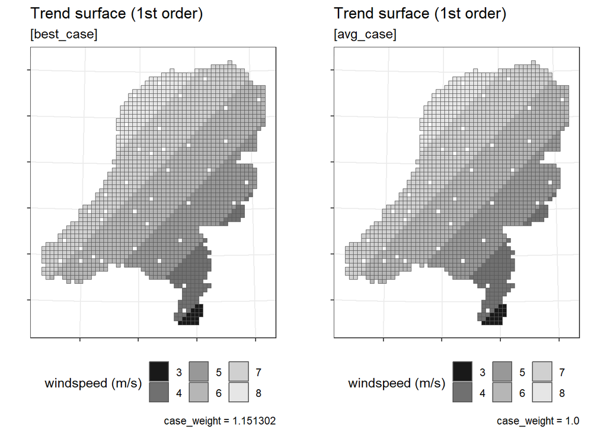

```r
grid.arrange(facet.trend_surface.linear)
```

[figure not shown]

```r
grid.arrange(facet.trend_surface.hyperbolic)
```

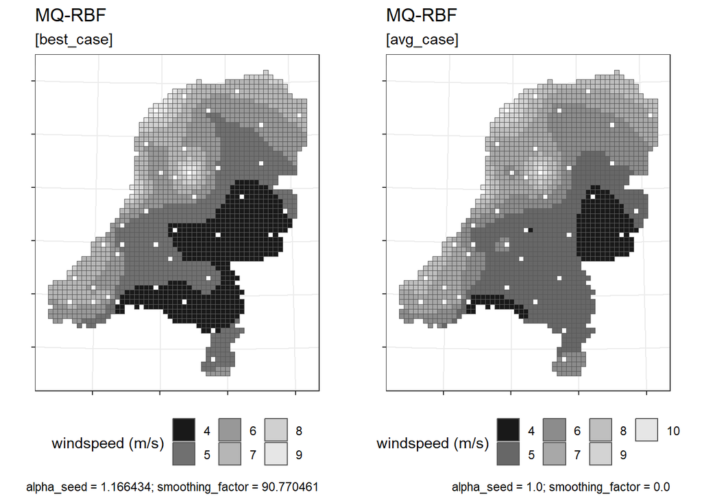

```r
grid.arrange(facet.mqrbf)
```

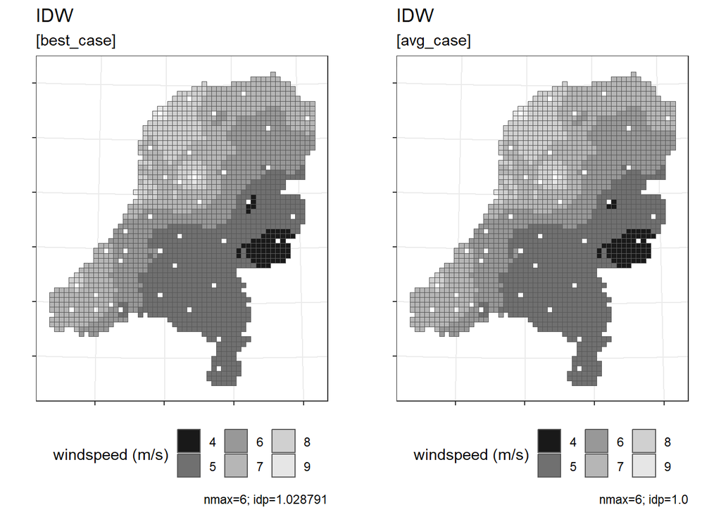

```r
grid.arrange(facet.idw)
```

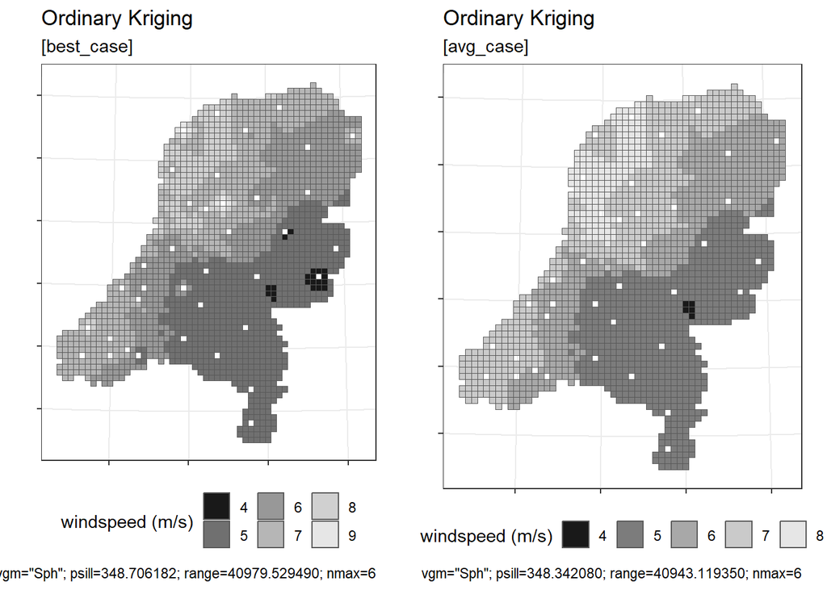

```r
grid.arrange(facet.od_kriging)
```

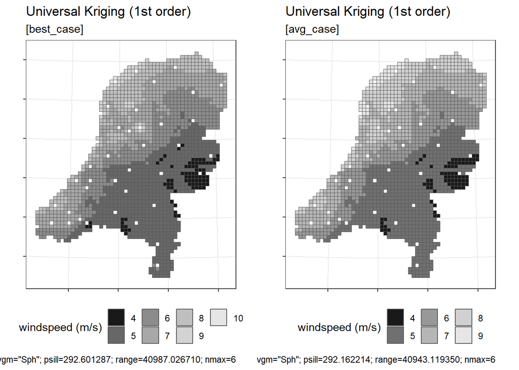

```r
grid.arrange(facet.u_kriging.linear)
```

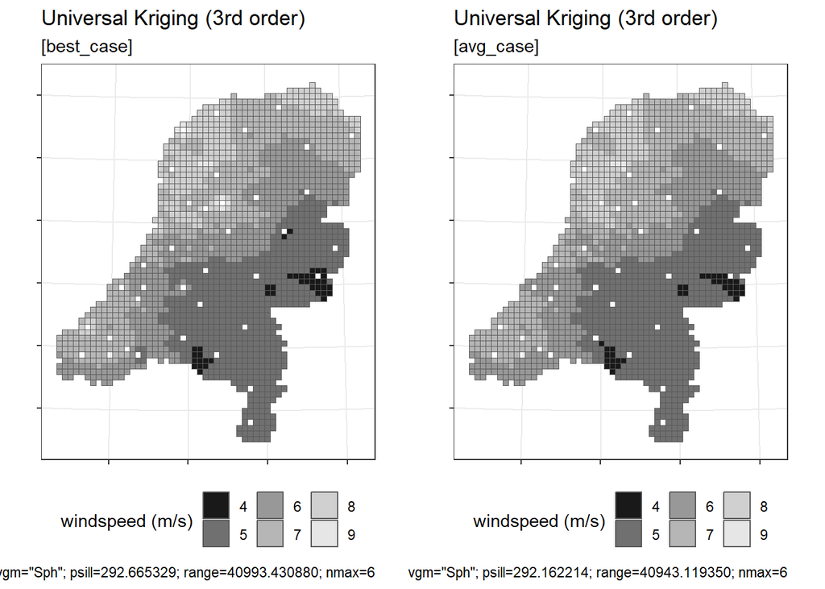

```r
grid.arrange(facet.u_kriging.hyperbolic)
```

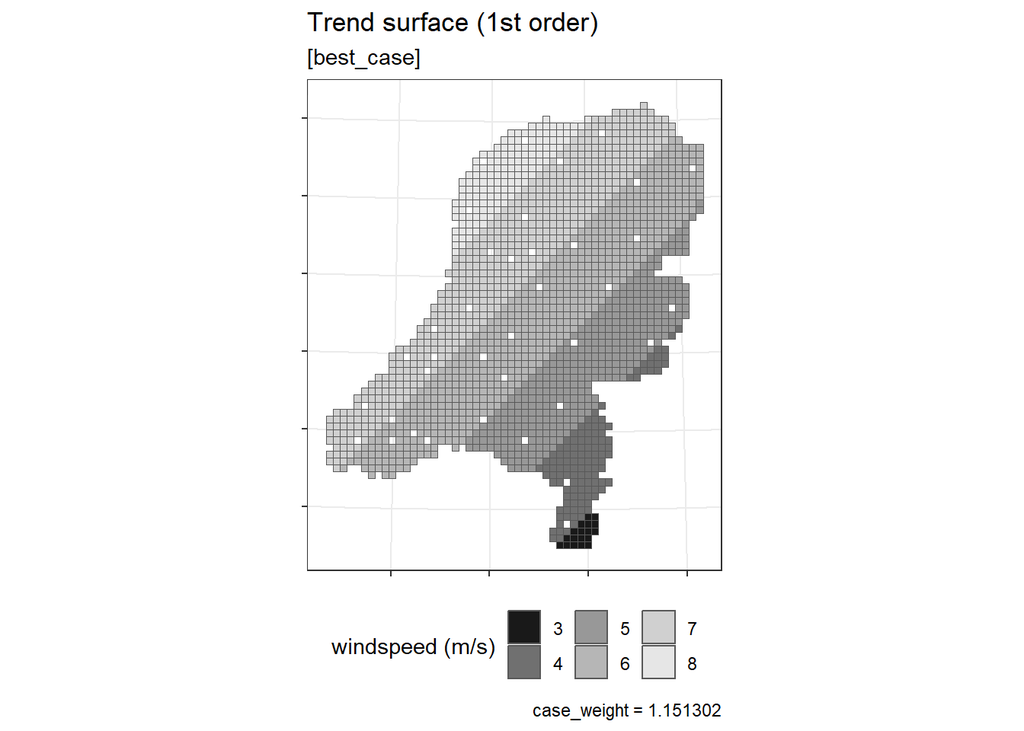

```r
map_plot.trend_surface.linear.best_case
```

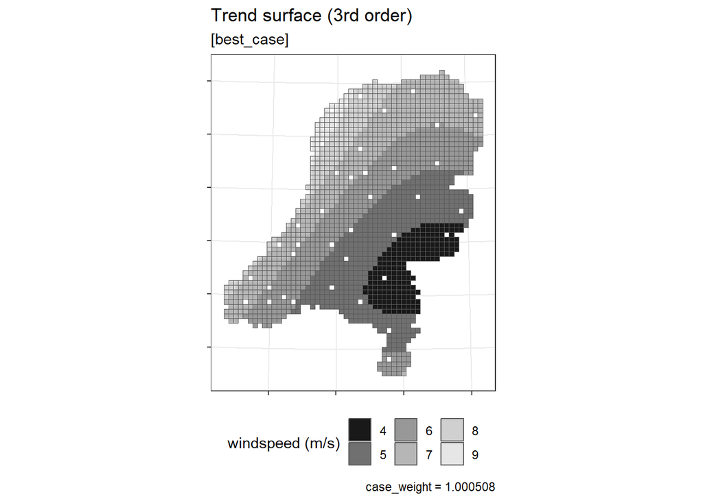

```r
map_plot.trend_surface.hyperbolic.best_case
```

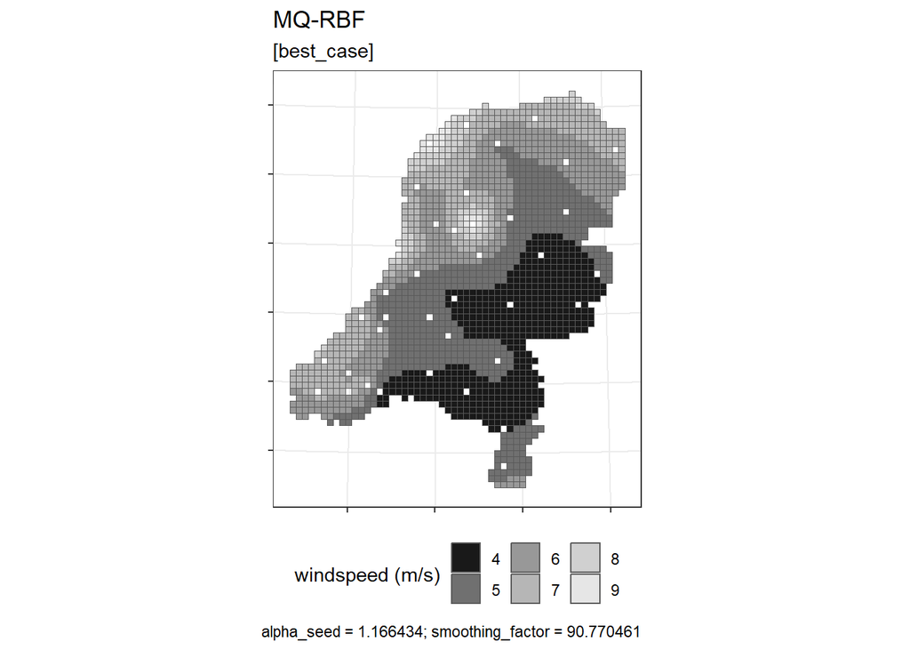

```r
map_plot.mqrbf.best_case
```

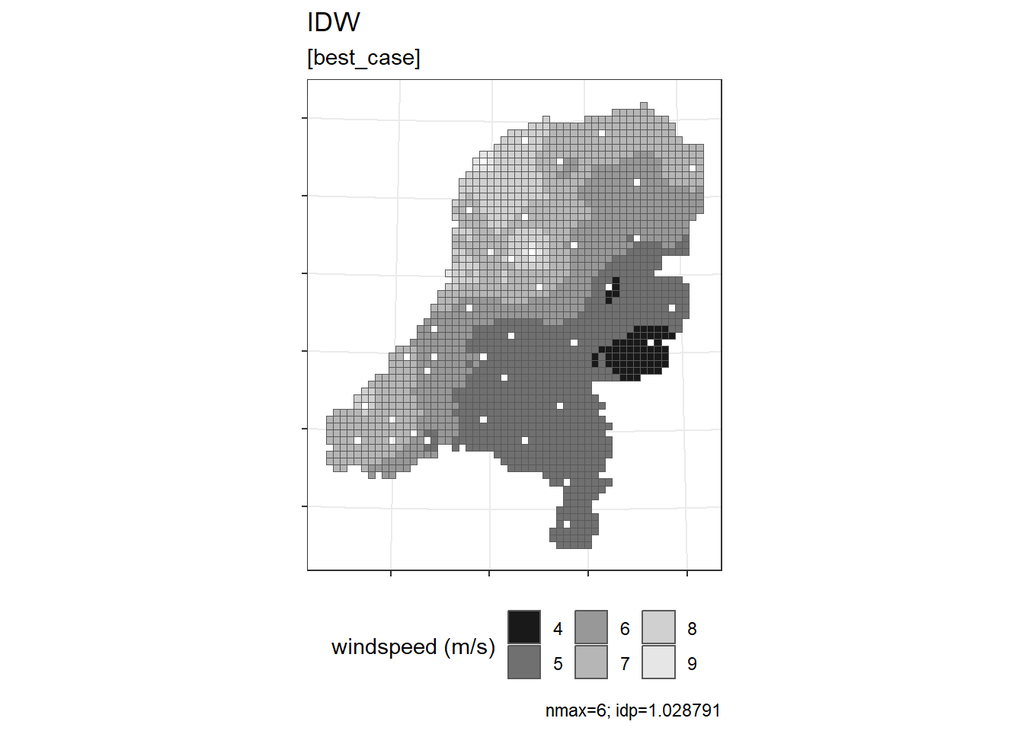

```r
map_plot.idw.best_case
```

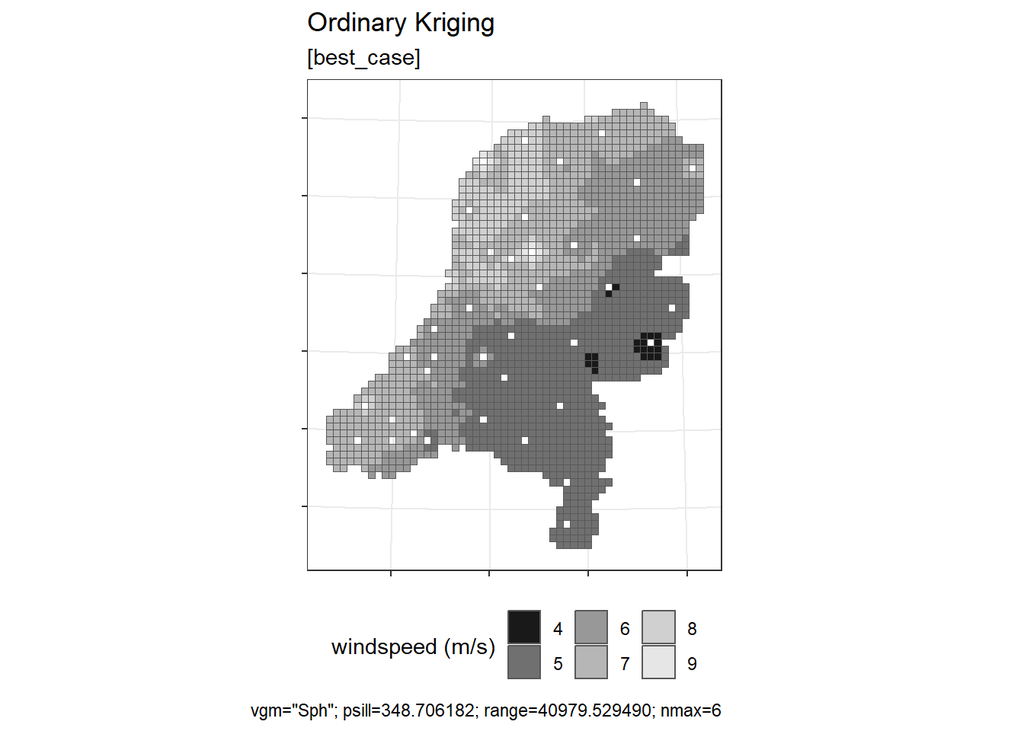

```r
map_plot.od_kriging.best_case
```

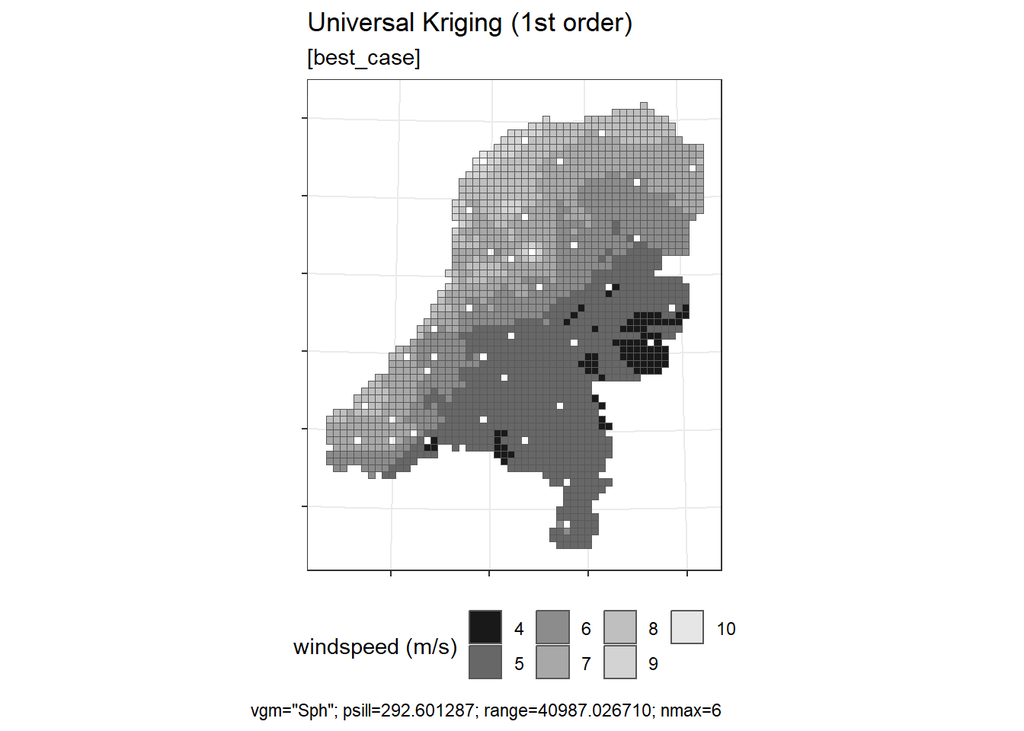

```r
map_plot.u_kriging.linear.best_case
```

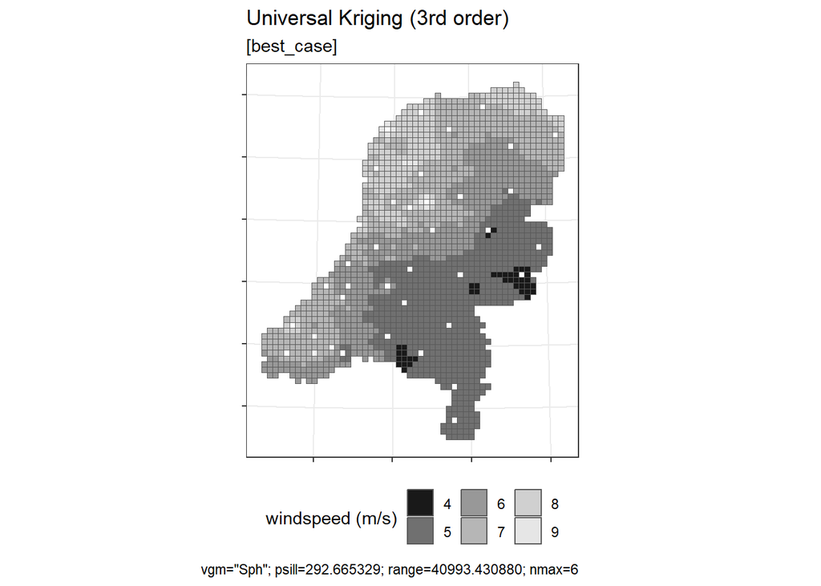

```r
map_plot.u_kriging.hyperbolic.best_case
```